# ECON 490 - Applied Machine Learning in Economics Problem Set 1 (100pts) - due date: Thursday, February 10

Adam Wawrowski (adamw4)

2/12/2022

# Answer 1

1. We would expect the performance of a flexible statistical learning method to be better than an inflexible one in this situation. Through the Central Limit Theorem, a large enough n will easily approximate the true distribution.
2. A flexible learning method would be worse than an inflexible one. There would be too much room for the method to find patterns that are due to pure chance.
3. A flexible learning method would be better than an inflexible one. A flexible method is inherently more capable to find the non-linear patterns in the variables.
4. A flexible learning method would be worse than an inflexible one. An flexible method would connect to the high variable points. It would cause overfitting.

# Answer 2

1. This is a regression problem. We are using the inputs (profit, employees, industry) to predict a quantity, namely, the CEO salary. In this situation, we are more interested in inference (Want to show the relationship between the variables). n is 500 and p is 3.
2. This is a classification problem. We want to use the inputs to classify a new product as a success or a failure. In particular, we are interested in prediction in terms of this classification. n is 20 and p is 13.
3. This is a regression problem. We are trying to use a model to predict a quantity percent change in the USD/Euro exchange rate. We are more interested in prediction in this situation. n is 52 and p is 3.

# Answer 3

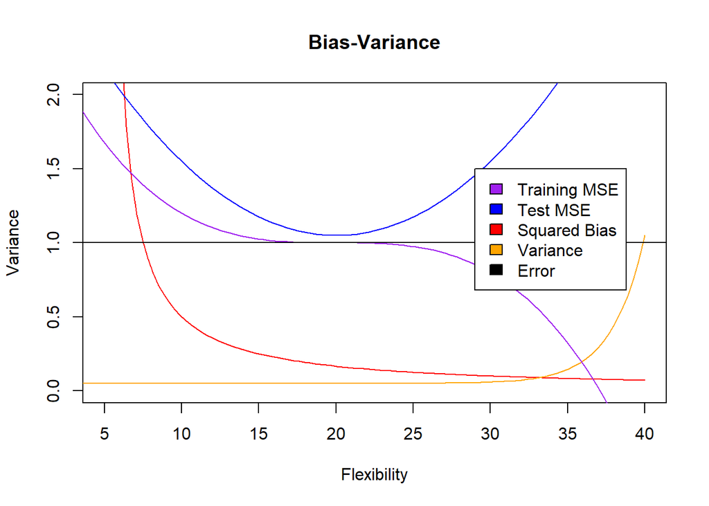

```r
curve(2.5/(x-5), from = 5, to = 40, ylim = c(0, 2), type="l",  main="Bias-Variance",
      xlab="Flexibility", ylab="Variance", col = "red")
#squared bias

curve(.01*(0.5*x^2-20*x+305), from = 2, to = 40, type="l",  main="main title",
      xlab="Flexibility", ylab="Variance", col = "blue", add = TRUE)
#test mse


curve(1.6^(x-40)+.05, from = 2, to = 40, type="l",  main="main title",
      xlab="Flexibility", ylab="Variance", col = "orange", add = TRUE)
#Variance

curve(-((x-20)^3/5000)+1, from = 2, to = 40, type="l",  main="main title",
      xlab="Flexibility", ylab="Variance", col = "purple", add = TRUE)
#training mse

abline(h = 1)
#error

legend(29, 1.5, legend=c("Training MSE", "Test MSE", "Squared Bias",
                         "Variance", "Error"), c("purple","blue","red","orange",
                                                 "black"))
```

2. Irreducible error stays constant, because it is an inherent part of the true population model. Training MSE decreases as flexibility increases, because it will closely follow the training data points as flexibility goes up. Test MSE decreases to a minimum and then increases as flexibility increases due to the fact that at some point when MSE is at its minimum, the model will then start to misinterpret pure chance in the data as patterns. Bias decreases as flexibility increases, because it will connect the data points as closely as it can. Variance increases as flexibility increases, because the model will become flexible enough to jump up and down between points.

# Answer 4

1. Here it would be recommended to create a table (or choose any way want to provide your answer):

Obs.

$X_1$

$X_2$

$X_3$

$d\big(obs, (0,0,0) \big)$

0

3

0

```
         3
```

2

0

0

```
         2
```

0

1

3

```
         3.162278
```

0

1

2

```
         2.236068
```

-1

0

1

```
         1.414214
```

1

1

1

```
        1.732051
```

2. The prediction with K = 1 is green. The closest point to (0, 0, 0) is (-1, 0, 1), which is classified as green.
3. The prediction with K = 3 is red. The three closest points are classified as 1 green and 2 red. 2 out of 3 are red.
4. The best value for K would be small, because a large value wouldn’t be flexible enough to predict the Bayes’ decision boundary.

# Question 5 (applied)[30p for part (c)]

This exercise relates to the College data set, It contains a number of variables for 777 different universities and colleges in the US. The variables are

- Private: Public/private indicator
- Apps: Number of applications received
- Accept: Number of applicants accepted
- Enroll: Number of new students enrolled
- Top10perc: New students from top 10
- Top25perc: New students from top 25
- F.Undergrad: Number of full-time undergraduates
- P.Undergrad: Number of part-time undergraduates
- Outstate: Out-of-state tuition
- Room.Board: Room and board costs
- Books: Estimated book costs
- Personal: Estimated personal spending
- PhD: Percent of faculty with Ph.D.’s
- Terminal: Percent of faculty with terminal degree
- S.F.Ratio: Student/faculty ratio
- perc.alumni: Percent of alumni who donate
- Expend: Instructional expenditure per student
- Grad.Rate: Graduation rate

Before reading the data into R, it can be viewed in Excel or a text editor.

1. Use the read.csv() function to read the data into R. Call the loaded data college. Make sure that you have the directory set to the correct location for the data. The R commands getwd() and setwd() may be helpful.

```r
college <- read.csv("College.csv")
```

2. Look at the data using the View() function. You should notice that the first column is just the name of each university. We don’t really want R to treat this as data. However, it may be handy to have these names for later. Try the following commands:

```r
rownames(college) <- college[, 1]
head(college)
```

```
##                                                         X Private Apps Accept
## Abilene Christian University Abilene Christian University     Yes 1660   1232
## Adelphi University                     Adelphi University     Yes 2186   1924
## Adrian College                             Adrian College     Yes 1428   1097
## Agnes Scott College                   Agnes Scott College     Yes  417    349
## Alaska Pacific University       Alaska Pacific University     Yes  193    146
## Albertson College                       Albertson College     Yes  587    479
##                              Enroll Top10perc Top25perc F.Undergrad P.Undergrad
## Abilene Christian University    721        23        52        2885         537
## Adelphi University              512        16        29        2683        1227
## Adrian College                  336        22        50        1036          99
## Agnes Scott College             137        60        89         510          63
## Alaska Pacific University        55        16        44         249         869
## Albertson College               158        38        62         678          41
##                              Outstate Room.Board Books Personal PhD Terminal
## Abilene Christian University     7440       3300   450     2200  70       78
## Adelphi University              12280       6450   750     1500  29       30
## Adrian College                  11250       3750   400     1165  53       66
## Agnes Scott College             12960       5450   450      875  92       97
## Alaska Pacific University        7560       4120   800     1500  76       72
## Albertson College               13500       3335   500      675  67       73
##                              S.F.Ratio perc.alumni Expend Grad.Rate
## Abilene Christian University      18.1          12   7041        60
## Adelphi University                12.2          16  10527        56
## Adrian College                    12.9          30   8735        54
## Agnes Scott College                7.7          37  19016        59
## Alaska Pacific University         11.9           2  10922        15
## Albertson College                  9.4          11   9727        55
```

You should see that there is now a row.names column with the name of each university recorded. This means that R has given each row a name corresponding to the appropriate university. R will not try to perform calculations on the row names. However, we still need to eliminate the first column in the data where the names are stored. Try

```r
rownames(college) <- college[, 1]
college <- college[, -1]
head(college)
```

```
##                              Private Apps Accept Enroll Top10perc Top25perc
## Abilene Christian University     Yes 1660   1232    721        23        52
## Adelphi University               Yes 2186   1924    512        16        29
## Adrian College                   Yes 1428   1097    336        22        50
## Agnes Scott College              Yes  417    349    137        60        89
## Alaska Pacific University        Yes  193    146     55        16        44
## Albertson College                Yes  587    479    158        38        62
##                              F.Undergrad P.Undergrad Outstate Room.Board Books
## Abilene Christian University        2885         537     7440       3300   450
## Adelphi University                  2683        1227    12280       6450   750
## Adrian College                      1036          99    11250       3750   400
## Agnes Scott College                  510          63    12960       5450   450
## Alaska Pacific University            249         869     7560       4120   800
## Albertson College                    678          41    13500       3335   500
##                              Personal PhD Terminal S.F.Ratio perc.alumni Expend
## Abilene Christian University     2200  70       78      18.1          12   7041
## Adelphi University               1500  29       30      12.2          16  10527
## Adrian College                   1165  53       66      12.9          30   8735
## Agnes Scott College               875  92       97       7.7          37  19016
## Alaska Pacific University        1500  76       72      11.9           2  10922
## Albertson College                 675  67       73       9.4          11   9727
##                              Grad.Rate
## Abilene Christian University        60
## Adelphi University                  56
## Adrian College                      54
## Agnes Scott College                 59
## Alaska Pacific University           15
## Albertson College                   55
```

Now you should see that the first data column is Private. Note that another column labeled row.names now appears before the Private column. However, this is not a data column but rather the name that R is giving to each row.

1. Use the summary() function to produce a numerical summary of the variables in the data set.

```r
summary(college)
```

```
##    Private               Apps           Accept          Enroll
##  Length:777         Min.   :   81   Min.   :   72   Min.   :  35
##  Class :character   1st Qu.:  776   1st Qu.:  604   1st Qu.: 242
##  Mode  :character   Median : 1558   Median : 1110   Median : 434
##                     Mean   : 3002   Mean   : 2019   Mean   : 780
##                     3rd Qu.: 3624   3rd Qu.: 2424   3rd Qu.: 902
##                     Max.   :48094   Max.   :26330   Max.   :6392
##    Top10perc       Top25perc      F.Undergrad     P.Undergrad
##  Min.   : 1.00   Min.   :  9.0   Min.   :  139   Min.   :    1.0
##  1st Qu.:15.00   1st Qu.: 41.0   1st Qu.:  992   1st Qu.:   95.0
##  Median :23.00   Median : 54.0   Median : 1707   Median :  353.0
##  Mean   :27.56   Mean   : 55.8   Mean   : 3700   Mean   :  855.3
##  3rd Qu.:35.00   3rd Qu.: 69.0   3rd Qu.: 4005   3rd Qu.:  967.0
##  Max.   :96.00   Max.   :100.0   Max.   :31643   Max.   :21836.0
##     Outstate       Room.Board       Books           Personal
##  Min.   : 2340   Min.   :1780   Min.   :  96.0   Min.   : 250
##  1st Qu.: 7320   1st Qu.:3597   1st Qu.: 470.0   1st Qu.: 850
##  Median : 9990   Median :4200   Median : 500.0   Median :1200
##  Mean   :10441   Mean   :4358   Mean   : 549.4   Mean   :1341
##  3rd Qu.:12925   3rd Qu.:5050   3rd Qu.: 600.0   3rd Qu.:1700
##  Max.   :21700   Max.   :8124   Max.   :2340.0   Max.   :6800
##       PhD            Terminal       S.F.Ratio      perc.alumni
##  Min.   :  8.00   Min.   : 24.0   Min.   : 2.50   Min.   : 0.00
##  1st Qu.: 62.00   1st Qu.: 71.0   1st Qu.:11.50   1st Qu.:13.00
##  Median : 75.00   Median : 82.0   Median :13.60   Median :21.00
##  Mean   : 72.66   Mean   : 79.7   Mean   :14.09   Mean   :22.74
##  3rd Qu.: 85.00   3rd Qu.: 92.0   3rd Qu.:16.50   3rd Qu.:31.00
##  Max.   :103.00   Max.   :100.0   Max.   :39.80   Max.   :64.00
##      Expend        Grad.Rate
##  Min.   : 3186   Min.   : 10.00
##  1st Qu.: 6751   1st Qu.: 53.00
##  Median : 8377   Median : 65.00
##  Mean   : 9660   Mean   : 65.46
##  3rd Qu.:10830   3rd Qu.: 78.00
##  Max.   :56233   Max.   :118.00
```

2. Use the pairs() function to produce a scatterplot matrix of the first ten columns or variables of the data. Recall that you can reference the first ten columns of a matrix A using A[,1:10].

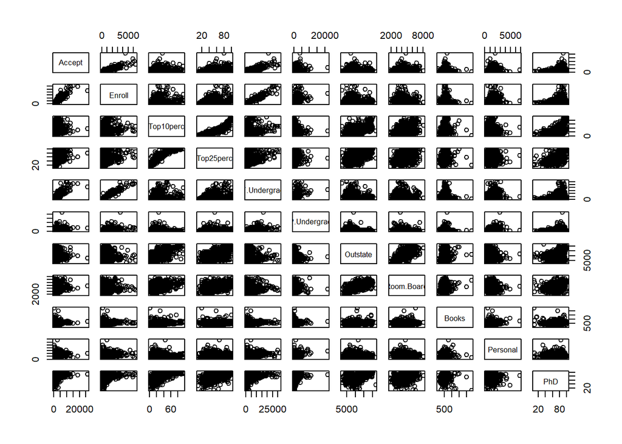

```r
pairs(college[, 3:13])
```

```r
# Could not pair column 'Private' under a non-numeric argument error
```

3. Use the plot() function to produce side-by-side boxplots of Outstate versus Private.

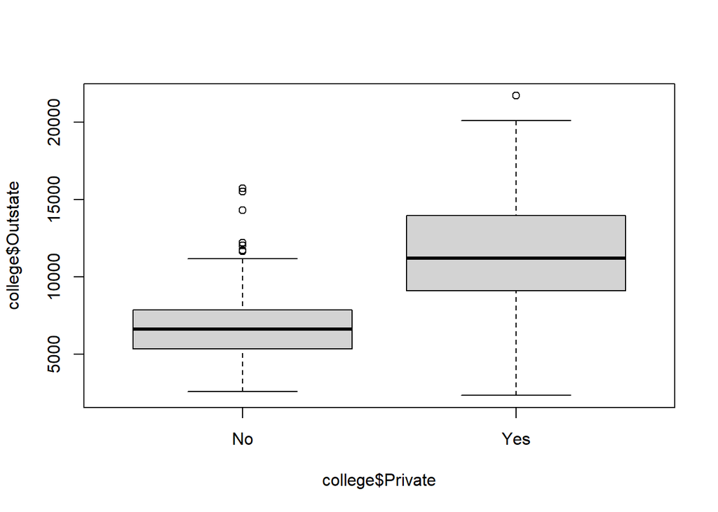

```r
boxplot(college$Outstate ~ college$Private)
```

4. Create a new qualitative variable, called Elite, by binning the Top10perc variable. We are going to divide universities into two groups based on whether or not the proportion of students coming from the top 10% of their high school classes exceeds 50%.

Use the summary() function to see how many elite universities there are. Now use the plot() function to produce side-by-side boxplots of Outstate versus Elite.

```r
Elite <- rep("No", nrow(college))
Elite[college$Top10perc > 50] <- "Yes"
Elite <- as.factor(Elite)
college <- data.frame(college, Elite)

summary(Elite)
```

```
##  No Yes
## 699  78
```

22. Use the hist() function to produce some histograms with differing numbers of bins for a few of the quantitative variables. You may find the command par(mfrow = c(2, 2)) useful: it will divide the print window into four regions so that four plots can be made simultaneously. Modifying the arguments to this function will divide the screen in other ways.

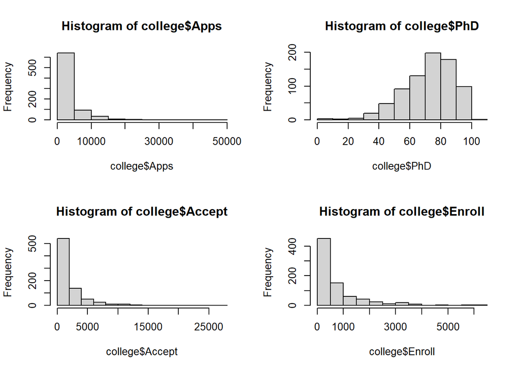

```r
par(mfrow = c(2, 2))


hist(college$Apps)
hist(college$PhD)
hist(college$Accept)
hist(college$Enroll)
```

6. Continue exploring the data, and provide a brief summary of what you discover.

Firstly, I created two boxplots: both focused on showing the Instructional Expenditure per student. On the left, whether a school is private, and on the right, whether a school is elite.

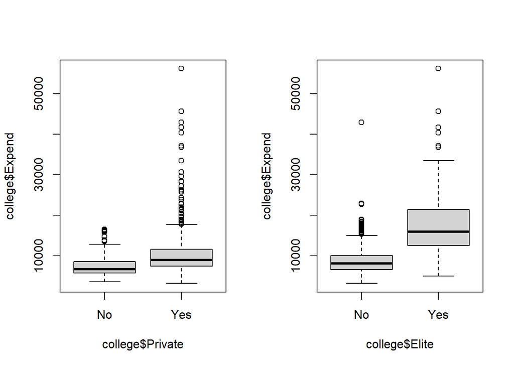

```r
Elite <- rep("No", nrow(college))
Elite[college$Top10perc > 50] <- "Yes"
Elite <- as.factor(Elite)
college <- data.frame(college, Elite)

par(mfrow = c(1, 2))
boxplot(college$Expend ~ college$Private)
boxplot(college$Expend ~ college$Elite)
```

In the Private box plot, the data shows that private schools in this data set have a slightly higher instructional expenditure per student on average. There is a problem though: there are numerous outliers outside of the box plot.In the Elite box plot, it is much more apparent that the Elite schools in this data set have a higher instructional expenditure per student on average. Can we use this data in an inferential study?